# IMDB Movie Reviews Sentiment analysis

2023-06-13

## Load required libraries

```r
library(tm) # topic modeling
library(e1071) # build model
library(gmodels) # cross tabulation
library(dplyr) # data manipulation
library(readr) # read data
library(tidytext)
library(SnowballC)
library(ggplot2)
```

## Import dataset

```r
movie_reviews <- read_csv("IMDB Dataset.csv")
```

## Explore the dataset

```r
glimpse(movie_reviews)
```

```
## Rows: 50,000
## Columns: 2
## $ review    <chr> "One of the other reviewers has mentioned that after watchin…
## $ sentiment <chr> "positive", "positive", "positive", "negative", "positive", …
```

```r
# see how is distribution of the sentiment
movie_reviews |>
  count(sentiment)
```

```
## # A tibble: 2 × 2
##   sentiment     n
##   <chr>     <int>
## 1 negative  25000
## 2 positive  25000
```

The data set has two columns and 50k observations

Tokenization

```r
review_df <- movie_reviews |>
 # select(review) |>
  unnest_tokens(word, review)

head(review_df)
```

```
## # A tibble: 6 × 2
##   sentiment word
##   <chr>     <chr>
## 1 positive  one
## 2 positive  of
## 3 positive  the
## 4 positive  other
## 5 positive  reviewers
## 6 positive  has
```

```r
review_df <- review_df |>
  mutate(stem = wordStem(word))

review_df <- review_df |>
  anti_join(stop_words[stop_words$lexicon =='snowball',],by = "word")
```

```r
review_df |>
  group_by(word) |>
  summarise(count = n()) |>
  arrange(desc(count)) |>
  head()
```

```
## # A tibble: 6 × 2
##   word   count
##   <chr>  <int>
## 1 br    201951
## 2 movie  86953
## 3 film   77608
## 4 one    53002
## 5 like   40150
## 6 just   35158
```

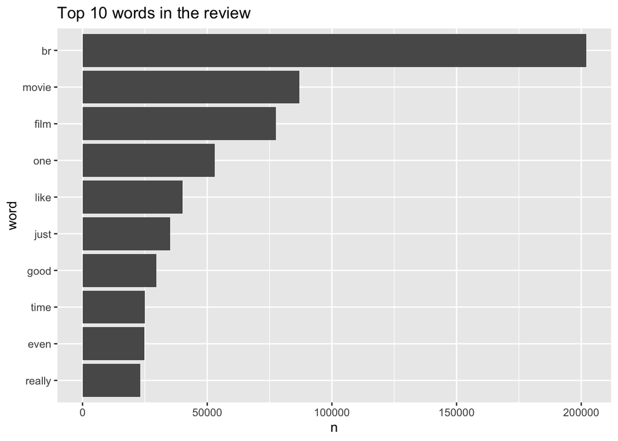

```r
# visualize

review_df |>
  count(word, sort = TRUE) |>
  mutate(word = reorder(word,n)) |>
  top_n(10) |>
  ggplot(aes(x = n, y = word))+
  geom_col()+
  labs(title = "Top 10 words in the review")
```

### Prepare for model building

```r
# convert the review texts into corpus

movie_reviews <- sample_n(movie_reviews, size = 15000)
review_corpus <- VCorpus(
VectorSource(movie_reviews$review))
print(review_corpus)
```

```
## <<VCorpus>>
## Metadata:  corpus specific: 0, document level (indexed): 0
## Content:  documents: 15000
```

```r
# check actual corpus in the text
as.character(review_corpus[[5]])
```

```
## [1] "I went along to this movie with some trepidation; the original is a masterpiece of both writing and acting and unfortunately my fears were realized. This is a humorless piece of work and I sat in the theater waiting for the wit and humor to begin- I'm still waiting, it seems. Updating the st…
```

#### data preparation for the model

```r
# clean the text
movie_revew_clean <- tm_map(review_corpus, content_transformer(tolower))
movie_revew_clean <- tm_map(movie_revew_clean, removeNumbers)
movie_revew_clean <- tm_map(movie_revew_clean, removeWords, stopwords())
movie_revew_clean <- tm_map(movie_revew_clean, removePunctuation)
movie_revew_clean <- tm_map(movie_revew_clean, stripWhitespace)
```

```r
as.character(movie_revew_clean[[5]])
```

```
## [1] " went along movie trepidation original masterpiece writing acting unfortunately fears realized humorless piece work sat theater waiting wit humor begin still waiting seems updating storyline present time just work altering characters absolute travesty introduce bette midlers character disapp…
```

```r
# Tokenize as document term matrix
movie_revew_dtm <- DocumentTermMatrix(movie_revew_clean)
```

#### Split the data set

```r
# split the data set to train the model
movie_reviews_train <- movie_revew_dtm[1:11250,] # 75%
movie_reviews_test <- movie_revew_dtm[11251:15000,] # 25%

movie_reviews_train_labels <- movie_reviews[1:11250,]$sentiment # 75%
movie_reviews_test_labels <- movie_reviews[11251:15000,]$sentiment# 25%

# check the distribution of train and test data

prop.table(table(movie_reviews_train_labels))
```

```
## movie_reviews_train_labels
##  negative  positive
## 0.5005333 0.4994667
```

```r
prop.table(table(movie_reviews_test_labels))
```

```
## movie_reviews_test_labels
##  negative  positive
## 0.5010667 0.4989333
```

```r
# find terms that appear 5 times or more in the review
review_freq_words_tr <- findFreqTerms(movie_reviews_train, 5)
review_freq_words_ts <- findFreqTerms(movie_reviews_test, 5)

# include only the frequent terms in the training and test data
movie_review_freq_train <- movie_reviews_train[, review_freq_words_tr]
movie_review_freq_test <- movie_reviews_test[, review_freq_words_ts]

# function that will check the presence of the each term
check_term <- function(x){
  x <- ifelse(x> 0, "Yes", "No")
}

review_train <- apply(movie_review_freq_train, MARGIN = 2, check_term)
review_test <- apply(movie_review_freq_test, MARGIN = 2, check_term)
```

### Build Model

I will use the Naive Bayes algorithm for this task. Naive Bayes model has some cool advanateges like: aive Bayes classifiers have several advantages for text classification tasks. Here are some of the key advantages:

Simplicity and Speed: Naive Bayes is a simple and fast algorithm that is computationally efficient. It scales well with large datasets and high-dimensional feature spaces, making it suitable for real-time or online applications.

Ease of Implementation: Naive Bayes classifiers are straightforward to implement and require minimal tuning of hyper parameters. They have a relatively low complexity compared to more complex machine learning algorithms, making them easy to understand and interpret.

Good Performance with Small Training Sets: Naive Bayes can perform well even with small training datasets. It works reasonably well in cases where the number of training examples is limited, making it useful when data availability is a constraint.

```r
review_model <- naiveBayes(review_train, movie_reviews_train_labels)
review_test_pred <- predict(review_model, review_test)

# create confusion matrix to see the accuracy of the model
CrossTable(review_test_pred,movie_reviews_test_labels,
           prop.chisq = FALSE,
           prop.t = FALSE, dnn = c("pred", "observed"))
```

```
##
##
##    Cell Contents
## |-------------------------|
## |                       N |
## |           N / Row Total |
## |           N / Col Total |
## |-------------------------|
##
##
## Total Observations in Table:  3750
##
##
##              | observed
##         pred |  negative |  positive | Row Total |
## -------------|-----------|-----------|-----------|
##     negative |      1604 |       306 |      1910 |
##              |     0.840 |     0.160 |     0.509 |
##              |     0.854 |     0.164 |           |
## -------------|-----------|-----------|-----------|
##     positive |       275 |      1565 |      1840 |
##              |     0.149 |     0.851 |     0.491 |
##              |     0.146 |     0.836 |           |
## -------------|-----------|-----------|-----------|
## Column Total |      1879 |      1871 |      3750 |
##              |     0.501 |     0.499 |           |
## -------------|-----------|-----------|-----------|
##
##
```

Our model is very good with better accuracy of 85% with test dataset.